# Accessing Remote Resources

## Web pages and data

I have mentioned before how one can access data files on your hard drive, but Python also allows you to access remote data, for example on the internet. The easiest way to do this is to use the requests module. To start off, you just can get the URL:

```python
import requests

response = requests.get('http://xkcd.com/353/')
```

`response` holds the response now. You can access the content as text via the text-property:

```python
import numpy as np
import matplotlib.pyplot as plt
%matplotlib inline
```

```python
print(response.text[:300])  # only print the first 300 characters
```

```
<!DOCTYPE html>
<html>
<head>
<script>
  (function(i,s,o,g,r,a,m){i['GoogleAnalyticsObject']=r;i[r]=i[r]||function(){
  (i[r].q=i[r].q||[]).push(arguments)},i[r].l=1*new Date();a=s.createElement(o),
  m=s.getElementsByTagName(o)[0];a.async=1;a.src=g;m.parentNode.insertBefore(a,m)
  })(window,documen
```

You can either just use this information directly, or in some cases you might want to write it to a file. Let's download one of the full resolution files for the Ice coverage data from Problem Set 2:

```python
r2 = requests.get('http://wwwstaff.ari.uni-heidelberg.de/kruijssen/pycourse/data/20060313.npy')
```

```python
r2.headers
```

```
{'Server': 'Apache/2.2.15 (Scientific Linux)', 'Date': 'Fri, 31 Mar 2017 14:04:59 GMT', 'Connection': 'close', 'ETag': '"ee2fa-4323d0-548deff606400"', 'Content-Type': 'text/plain', 'Content-Length': '4400080', 'Last-Modified': 'Sun, 19 Feb 2017 09:44:48 GMT', 'Accept-Ranges': 'bytes'}
```

```python
r2.text[:200]
```

```
"\x93NUMPY\x01\x00F\x00{'descr': '>f4', 'fortran_order': False, 'shape': (1100, 1000), }    \n\x00\x00\x00\x00\x00\x00\x00\x00\x00\x00\x00\x00\x00\x00\x00\x00\x00\x00\x00\x00\x00\x00\x00\x00\x00\x00\x00\x00\x00\x00\x00\x00\x00\x00\x00\x00\x00\x00\x00\x00\x00\x00\x00\x00\x00\x00\x00\x00\x00\x00\x00\x…
```

However, this doesn't seem to be actual *text*. Instead, its a binary format. The binary data of the response can be accessed via

```python
r2.content[:200]
```

```
b"\x93NUMPY\x01\x00F\x00{'descr': '>f4', 'fortran_order': False, 'shape': (1100, 1000), }    \n\x00\x00\x00\x00\x00\x00\x00\x00\x00\x00\x00\x00\x00\x00\x00\x00\x00\x00\x00\x00\x00\x00\x00\x00\x00\x00\x00\x00\x00\x00\x00\x00\x00\x00\x00\x00\x00\x00\x00\x00\x00\x00\x00\x00\x00\x00\x00\x00\x00\x00\x00\…
```

Note the little `b` at the beginning indicating a binary byte-string.

Now we can open a new (binary) file and download the data to the file.

```python
with open('20060313.npy', 'wb') as f:
    f.write(r2.content)
```

Let's now load and plot the data:

```python
import numpy as np
data = np.load('20060313.npy')
```

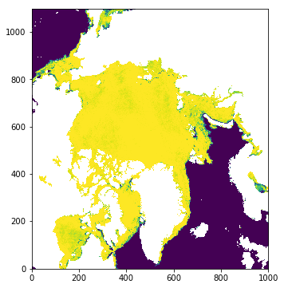

```python
%matplotlib inline
import matplotlib.pyplot as plt
plt.figure(figsize=(6,6))
plt.imshow(data, origin='lower')
```

## APIs

Imagine that you want to access some data online. A number of websites now offer an "Application programming interface" (or API) which is basically a way of accessing data is a machine-readable way. An example for weather data is http://openweathermap.org/API

Let's however take an example from theoretical Astrophysics, which is the [Illustris simulation](http://www.illustris-project.org). *The routines we use below are presented and described on their web page.*

Illustris is a cosmological simulation. It traces the positions and the formation of components such as dark matter, gas and stars across cosmic time from high-redshift to today. Extracting data at various cosmic times (=redshifts $z$), one can study, for instance, the gravitational collapse and merging history of galaxies and clusters of galaxies.

We show here how to extract the dark matter particles inside haloes you can pick from the [illustris explorer](http://www.illustris-project.org/explorer) tool.

Once we have picked a halo ID, we can download the data. For the access, we need the access key. This was generated for the use by this course (normally, every user has their own key.)

```python
headers={"api-key":"8a8338834d046c14e6d8c15c24f70dda"} # 8a833... = key for Uni HD python course
```

```python
import requests
r = requests.get('http://www.illustris-project.org/api/', headers=headers)
print (r.text[:400])
```

```
{"simulations":[{"name":"Illustris-1","num_snapshots":134,"url":"http://www.illustris-project.org/api/Illustris-1/"},{"name":"Illustris-1-Dark","num_snapshots":136,"url":"http://www.illustris-project.org/api/Illustris-1-Dark/"},{"name":"Illustris-2","num_snapshots":136,"url":"http://www.illustris-pr…
```

This is much shorter, but still not ideal for reading into Python in this form. The output details the available simulations and the number of snapshots in a format called **JSON ("JavaScript Object Notation")**. Python includes a library to easily read in this data:

```python
import json
data = json.loads(r.text)
```

```python
data
```

```
{'simulations': [{'name': 'Illustris-1',
   'num_snapshots': 134,
   'url': 'http://www.illustris-project.org/api/Illustris-1/'},
  {'name': 'Illustris-1-Dark',
   'num_snapshots': 136,
   'url': 'http://www.illustris-project.org/api/Illustris-1-Dark/'},
  {'name': 'Illustris-2',
   'num_snapshots': 136,
   'url': 'http://www.illustris-project.org/api/Illustris-2/'},
  {'name': 'Illustris-2-Dark',
   'num_snapshots': 136,
   'url': 'http://www.illustris-project.org/api/Illustris-2-Dark/'},
  {'name': 'Illustris-3',
   'num_snapshots': 136,
   'url': 'http://www.illustris-project.org/api/Illustris-3/'},
  {'name': 'Illustris-3-Dark',
   'num_snapshots': 136,
   'url': 'http://www.illustris-project.org/api/Illustris-3-Dark/'},
  {'name': 'Illustris-1-Subbox0',
   'num_snapshots': 3970,
   'url': 'http://www.illustris-project.org/api/Illustris-1-Subbox0/'},
  {'name': 'Illustris-1-Subbox1',
   'num_snapshots': 3969,
   'url': 'http://www.illustris-project.org/api/Illustris-1-Subbox1/'},
  {'name': 'Illustris-1-Subbox2',
   'num_snapshots': 3972,
   'url': 'http://www.illustris-project.org/api/Illustris-1-Subbox2/'},
  {'name': 'Illustris-1-Subbox3',
   'num_snapshots': 3970,
   'url': 'http://www.illustris-project.org/api/Illustris-1-Subbox3/'},
  {'name': 'Illustris-2-Subbox0',
   'num_snapshots': 2265,
   'url': 'http://www.illustris-project.org/api/Illustris-2-Subbox0/'},
  {'name': 'Illustris-2-Subbox1',
   'num_snapshots': 2265,
   'url': 'http://www.illustris-project.org/api/Illustris-2-Subbox1/'},
  {'name': 'Illustris-2-Subbox2',
   'num_snapshots': 2264,
   'url': 'http://www.illustris-project.org/api/Illustris-2-Subbox2/'},
  {'name': 'Illustris-2-Subbox3',
   'num_snapshots': 2265,
   'url': 'http://www.illustris-project.org/api/Illustris-2-Subbox3/'},
  {'name': 'Illustris-3-Subbox0',
   'num_snapshots': 1426,
   'url': 'http://www.illustris-project.org/api/Illustris-3-Subbox0/'},
  {'name': 'Illustris-3-Subbox1',
   'num_snapshots': 1426,
   'url': 'http://www.illustris-project.org/api/Illustris-3-Subbox1/'},
  {'name': 'Illustris-3-Subbox2',
   'num_snapshots': 1426,
   'url': 'http://www.illustris-project.org/api/Illustris-3-Subbox2/'},
  {'name': 'Illustris-3-Subbox3',
   'num_snapshots': 1426,
   'url': 'http://www.illustris-project.org/api/Illustris-3-Subbox3/'}]}
```

In fact, such a dictionary can be obtained at every level in the data tree (try, e.g., the next one http://www.illustris-project.org/api/Illustris-1/ )

Now is the time to go to the Explorer and pick a (preferably massive) halo. Take note of the ID.

Note that some haloes are situated at the boundary, make sure the object can be easily extracted.

Specifications of data fields can be found [here](http://www.illustris-project.org/data/docs/specifications/).

```python
id = 75               # choose your ID of the halo    75?   default=1030
redshift = 0.5          # choose a redshift, will be converted to snapshot automatically.
params = {'dm':'Coordinates'}

url = "http://www.illustris-project.org/api/Illustris-1/snapshots/z=" + str(redshift) + "/subhalos/" + str(id)

# read the parameters of the subhalo in the json format
subhalo = requests.get(url, headers=headers).json()

# read the cutout of the subhalo into memory
cutout  = requests.get(url+"/cutout.hdf5", headers=headers, params=params)

# extract the filename from the header information and build the output name
filename= cutout.headers['content-disposition'].split("filename=")[1]
outname=filename.split(".hdf5")[0]+"_z="+str(redshift)+".hdf5"

# save the cutout to disk, use 'outname'
with open(outname, 'wb') as f:
    f.write(cutout.content)
```

The variable subhalo is a dictionary:

```python
subhalo['mass_log_msun']
```

```
10.803635551919267
```

The illustris data are in the [hdf5](https://support.hdfgroup.org/HDF5/) format. We need to write them to disk and reload them. For this, we need to import the h5py package and read the file using *h5py.File*

The result is again a dictionary. We are here interested in the PartType1 key (dark matter), in particular the Coordinates.

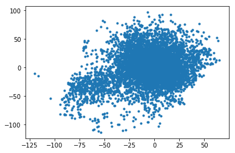

```python
import h5py

with h5py.File(outname) as f:
    # we subtract the centre of the halo (extracted from the dictionary information in subhalo)
    # from the particle coordinates
    dx = f['PartType1']['Coordinates'][:,0] - subhalo['pos_x']
    dy = f['PartType1']['Coordinates'][:,1] - subhalo['pos_y']
    dz = f['PartType1']['Coordinates'][:,2] - subhalo['pos_z']

import matplotlib.pylab as plt
plt.plot(dx,dy,'.')
```

## Exercise

Consider subhalo 75 or 1030 (choose) at the three redshifts z=0 (snapshot 135), z=0.5 (snapshot 103) and z=1 (snapshot 85).

1. Look at the distribution of the dark matter particles. Determine the total dark matter mass inside R=1 Mpc (ignore here the redshift and Hubble constant scaling of these units).
2. Determine the density profiles $\rho = \frac{d N}{dV}$ for the halo at these three redshifts. $dN$ is the number of objects in the Volume $dV$. Remember: *plt.hist* can be used to build histograms.

   Can you find a redshift dependence?
3. (with time) Fit the functional form

   $\rho(r)=\frac{A}{\frac{r}{r_s} (1+\frac{r}{r_s})^n}$

   with n=3 or n=4 to the density profiles. Choose "sensible" fitting intervals.

**Note:** To simplify things, the following function was provided by the illustris project.

It takes a path (such as 'url' above) and returns either the header information, or downloads binary data and returns the file name.

(from the illustris documentation [here](http://www.illustris-project.org/data/docs/api/) )

```python
def get(path, params=None):
    # make HTTP GET request to path
    headers = {"api-key":"8a8338834d046c14e6d8c15c24f70dda"}
    r = requests.get(path, params=params, headers=headers)

    # raise exception if response code is not HTTP SUCCESS (200)
    r.raise_for_status()

    if r.headers['content-type'] == 'application/json':
        return r.json() # parse json responses automatically

    if 'content-disposition' in r.headers:
        filename = r.headers['content-disposition'].split("filename=")[1]
        with open(filename, 'wb') as f:
            f.write(r.content)
        return filename # return the filename string

    return r
```

Here is an **example** how the function **get(path)** can be used:

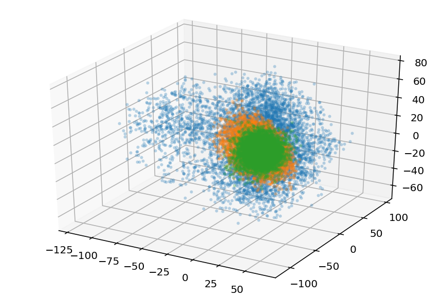

```
6.00138 x 10^10 Msun
```

```python
id = 75
snapshot = [85,103,135]

def getsnapshot(id,snap):
    params = {'dm':'Coordinates'}
    url = "http://www.illustris-project.org/api/Illustris-1/snapshots/" + str(snap) + "/subhalos/" + str(id)
    sub = get(url)                                    # get json response of subhalo properties
    return sub,get(url + "/cutout.hdf5",params) # get and save HDF5 cutout file

sub,saved_filename = getsnapshot(id,snapshot[1])
with h5py.File(saved_filename) as f:              # read coordinates
    dx = f['PartType1']['Coordinates'][:,0] - sub['pos_x']
    dy = f['PartType1']['Coordinates'][:,1] - sub['pos_y']
    dz = f['PartType1']['Coordinates'][:,2] - sub['pos_z']

from mpl_toolkits.mplot3d import Axes3D
%matplotlib notebook
# plt.plot(dx,dy,'.') ## NORMAL PLOT, the 3D plot below is optional
fig=plt.figure()
ax = Axes3D(fig)
ax.plot(dx,dy,dz,marker='.',linestyle='none', alpha=0.3, mew=0)
rr = np.sqrt(dx**2.+dy**2.+dz**2.)
inmpc = rr < 1000.
m = 6.3e6
print(str(len(rr[inmpc])*m/1.e10)+' x 10^10 Msun')
```

```python
sub,saved_filename = getsnapshot(id,snapshot[0])
with h5py.File(saved_filename) as f:              # read coordinates
    dx = f['PartType1']['Coordinates'][:,0] - sub['pos_x']
    dy = f['PartType1']['Coordinates'][:,1] - sub['pos_y']
    dz = f['PartType1']['Coordinates'][:,2] - sub['pos_z']
# plt.plot(dx,dy,'.') ## NORMAL PLOT, the 3D plot below is optional
ax.plot(dx,dy,dz,marker='.',linestyle='none', alpha=0.3, mew=0)
rr = np.sqrt(dx**2.+dy**2.+dz**2.)
inmpc = rr < 1000.
m = 6.3e6
print(str(len(rr[inmpc])*m/1.e10)+' x 10^10 Msun')
```

```
3.69117 x 10^10 Msun
```

```python
sub,saved_filename = getsnapshot(id,snapshot[2])
with h5py.File(saved_filename) as f:              # read coordinates
    dx = f['PartType1']['Coordinates'][:,0] - sub['pos_x']
    dy = f['PartType1']['Coordinates'][:,1] - sub['pos_y']
    dz = f['PartType1']['Coordinates'][:,2] - sub['pos_z']
# plt.plot(dx,dy,'.') ## NORMAL PLOT, the 3D plot below is optional
ax.plot(dx,dy,dz,marker='.',linestyle='none', alpha=0.3, mew=0)
rr = np.sqrt(dx**2.+dy**2.+dz**2.)
inmpc = rr < 1000.
m = 6.3e6
print(str(len(rr[inmpc])*m/1.e10)+' x 10^10 Msun')
```

```
8.35002 x 10^10 Msun
```

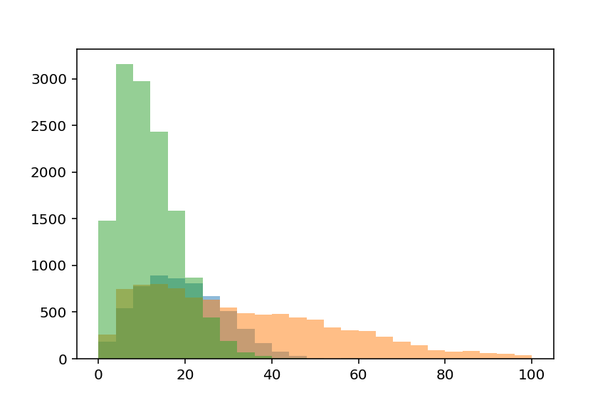

```python
id = 75
nbins = 25
rmin = 0.
rmax = 100.
xbins = np.zeros((3,nbins))
hist = 0.*xbins
ehist = 0.*xbins
vol = 0.*xbins
for i in range(len(snapshot)):
    sub,saved_filename = getsnapshot(id,snapshot[i])
    with h5py.File(saved_filename) as f:              # read coordinates
        dx = f['PartType1']['Coordinates'][:,0] - sub['pos_x']
        dy = f['PartType1']['Coordinates'][:,1] - sub['pos_y']
        dz = f['PartType1']['Coordinates'][:,2] - sub['pos_z']
    rr = np.sqrt(dx**2.+dy**2.+dz**2.)
    count,x,ax=plt.hist(rr,bins=nbins,range=(0,rmax),alpha=0.5)
    xbins[i,:]=0.5*(x[1:]+x[:-1])
    vol[i,:]=4.*np.pi/3.*(x[1:]**3.-x[:-1]**3.)
    hist[i,:]=count/vol[i,:]
    ehist[i,:]=np.sqrt(count)/vol[i,:]
```

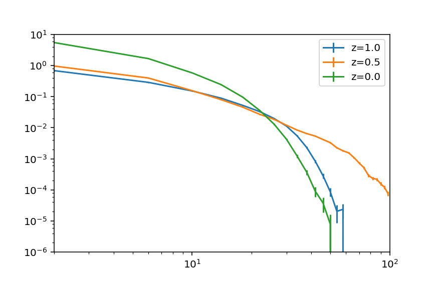

```python
for i in range(len(snapshot)):
    plt.errorbar(xbins[i,:],hist[i,:],yerr=ehist[i,:])
plt.xscale('log')
plt.yscale('log')
plt.xlim(2,100)
plt.ylim(1e-6,10)
plt.legend(['z=1.0','z=0.5','z=0.0'])
```

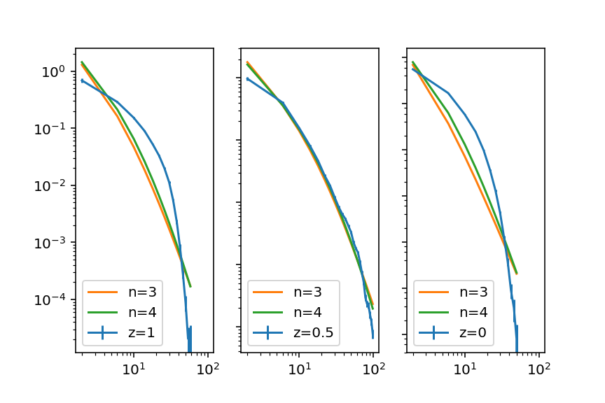

```
[ 0.58295618  8.42298973] [  0.29252627  15.8446109 ]
[  0.23955936  19.87308673] [  0.11805444  34.70743129]
[ 25.14225625   2.78072683] [ 5.72345691  7.27510133]
```

```python
from scipy.optimize import curve_fit
def nfw3(r,a,rs):
    nfw=a/((r/rs)*(1.+(r/rs))**3.)
    return nfw

def nfw4(r,a,rs):
    nfw=a/((r/rs)*(1.+(r/rs))**4.)
    return nfw

labels = ['z=1','z=0.5','z=0']
fig, axarr = plt.subplots(1,3)
for i in range(len(snapshot)):
    valid = ehist[i,:]>0
    popt3,pcov3 = curve_fit(nfw3,xbins[i,valid],hist[i,valid],sigma=ehist[i,valid])
    popt4,pcov4 = curve_fit(nfw4,xbins[i,valid],hist[i,valid],sigma=ehist[i,valid])
    axarr[i].errorbar(xbins[i,:],hist[i,:],yerr=ehist[i,:])
    axarr[i].set_xscale('log')
    axarr[i].set_yscale('log')
    if i>0:
        a = plt.setp(axarr[i].get_yticklabels(), visible=False)
    axarr[i].plot(xbins[i,valid],nfw3(xbins[i,valid],*popt3))
    axarr[i].plot(xbins[i,valid],nfw4(xbins[i,valid],*popt4))
    axarr[i].legend(('n=3','n=4',labels[i]))
    print(popt3,popt4)
```